# Семинар по смешанным моделям

Anna Klezovich

31.07.2019

Импортируем все нужные пакеты

## Politeness

```r
polite <- read.csv("http://www.bodowinter.com/tutorial/politeness_data.csv")
head(polite)
```

```
##   subject gender scenario attitude frequency
## 1      F1      F        1      pol     213.3
## 2      F1      F        1      inf     204.5
## 3      F1      F        2      pol     285.1
## 4      F1      F        2      inf     259.7
## 5      F1      F        3      pol     203.9
## 6      F1      F        3      inf     286.9
```

```r
str(polite)
```

```
## 'data.frame':    84 obs. of  5 variables:
##  $ subject  : Factor w/ 6 levels "F1","F2","F3",..: 1 1 1 1 1 1 1 1 1 1 ...
##  $ gender   : Factor w/ 2 levels "F","M": 1 1 1 1 1 1 1 1 1 1 ...
##  $ scenario : int  1 1 2 2 3 3 4 4 5 5 ...
##  $ attitude : Factor w/ 2 levels "inf","pol": 2 1 2 1 2 1 2 1 2 1 ...
##  $ frequency: num  213 204 285 260 204 ...
```

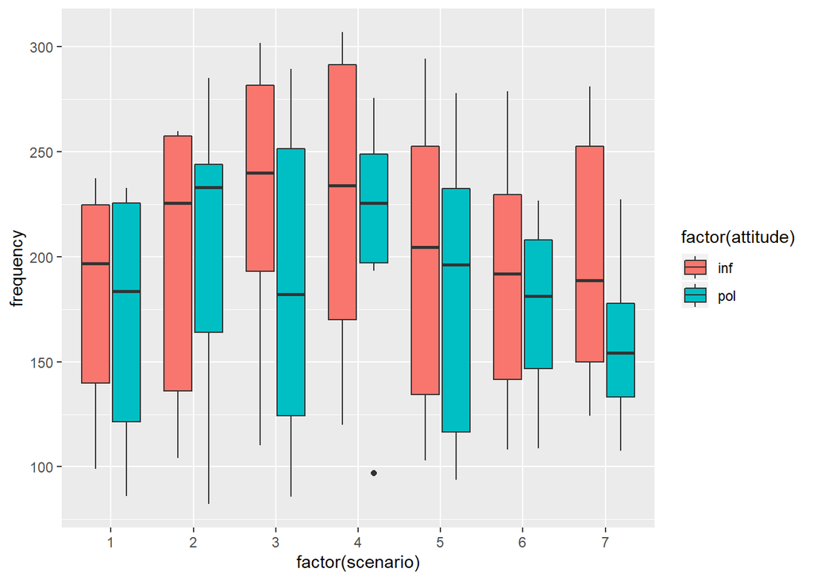

```r
ggplot(polite, aes(x = factor(scenario), y = frequency, fill = factor(attitude)))+geom_boxplot()
```

Визуализируем переменные, которые мы хотим считать за рандомные эффекты

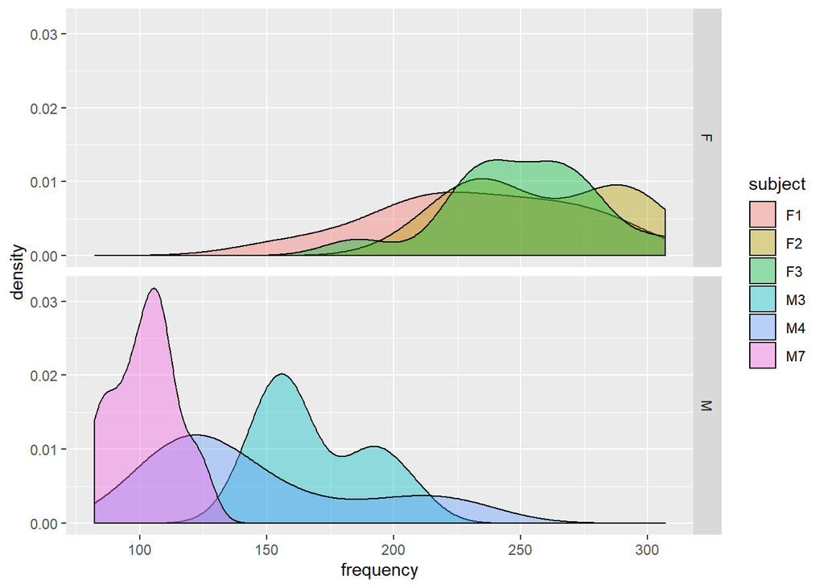

```r
ggplot(polite, aes(x=frequency, fill=subject)) +
geom_density(alpha=0.4)+facet_grid(gender ~ .)
```

```r
fit_1 <- lmer(frequency ~ attitude + (1|subject) + (1|scenario), polite)
summary(fit_1)
```

```
## Linear mixed model fit by REML ['lmerMod']
## Formula: frequency ~ attitude + (1 | subject) + (1 | scenario)
##    Data: polite
##
## REML criterion at convergence: 793.5
##
## Scaled residuals:
##     Min      1Q  Median      3Q     Max
## -2.2006 -0.5817 -0.0639  0.5625  3.4385
##
## Random effects:
##  Groups   Name        Variance Std.Dev.
##  scenario (Intercept)  219     14.80
##  subject  (Intercept) 4015     63.36
##  Residual              646     25.42
## Number of obs: 83, groups:  scenario, 7; subject, 6
##
## Fixed effects:
##             Estimate Std. Error t value
## (Intercept)  202.588     26.754   7.572
## attitudepol  -19.695      5.585  -3.527
##
## Correlation of Fixed Effects:
##             (Intr)
## attitudepol -0.103
```

А что будет, если мы включим пол в основные эффекты?

```r
fit_2 <- lmer(frequency ~ attitude + gender + (1|subject) + (1|scenario), polite)
summary(fit_2)
```

```
## Linear mixed model fit by REML ['lmerMod']
## Formula: frequency ~ attitude + gender + (1 | subject) + (1 | scenario)
##    Data: polite
##
## REML criterion at convergence: 775.5
##
## Scaled residuals:
##     Min      1Q  Median      3Q     Max
## -2.2591 -0.6235 -0.0773  0.5389  3.4795
##
## Random effects:
##  Groups   Name        Variance Std.Dev.
##  scenario (Intercept) 219.3    14.81
##  subject  (Intercept) 615.7    24.81
##  Residual             645.9    25.41
## Number of obs: 83, groups:  scenario, 7; subject, 6
##
## Fixed effects:
##             Estimate Std. Error t value
## (Intercept)  256.846     16.116  15.937
## attitudepol  -19.721      5.584  -3.532
## genderM     -108.516     21.015  -5.164
##
## Correlation of Fixed Effects:
##             (Intr) atttdp
## attitudepol -0.173
## genderM     -0.652  0.004
```

Определения фиксированных и случайных эффектов из разных умных книжек:

1. Fixed effects are constant across individuals, and random effects vary. (Kreft & de Leeuw 1998)
2. Effects are fixed if they are interesting in themselves or random if there is interest in the underlying population. (Searle, Casella & McCulloch 1992)
3. When a sample exhausts the population, the corresponding variable is fixed; when the sample is a small (i.e., negligible) part of the population the corresponding variable is random (Green & Tukey 1960)
4. Fixed effects are estimated using least squares (or, more generally, maximum likelihood) and random effects are estimated with **shrinkage** (Snijders and Bosker 1999)

Какая из этих моделей лучше?

```r
AIC(fit_1)
```

```
## [1] 803.4536
```

```r
AIC(fit_2)
```

```
## [1] 787.4547
```

Проинтерпретируйте результаты лучшей модели способами, которые мы обсудили ранее.

## Speed dating

```r
load('speed_dating.RData')
head(speed_dating)
```

```
## # A tibble: 6 x 30
##     iid id_win_wave sex     idg condtn  wave n_met_in_wave position
##   <int>       <int> <fct> <int>  <int> <int>         <int>    <int>
## 1     1           1 Fema~     1      1     1            10        7
## 2     1           1 Fema~     1      1     1            10        7
## 3     1           1 Fema~     1      1     1            10        7
## 4     1           1 Fema~     1      1     1            10        7
## 5     1           1 Fema~     1      1     1            10        7
## 6     1           1 Fema~     1      1     1            10        7
## # ... with 22 more variables: positin1 <chr>, order <int>, partner <int>,
## #   partner_id <int>, match <int>, int_corr <dbl>, samerace <fct>,
## #   partner_age <int>, partner_race <int>, attractive <dbl>,
## #   sincere <dbl>, intelligent <dbl>, fun <dbl>, ambitious <dbl>,
## #   shared_interests <dbl>, decision <fct>, attractive_sc <dbl>,
## #   sincere_sc <dbl>, intelligent_sc <dbl>, fun_sc <dbl>,
## #   ambitious_sc <dbl>, shared_interests_sc <dbl>
```

```r
#str(speed_dating)
#summary(speed_dating)
```

Подготовим данные - уже не надо, там есть дублированные переменные, которые scaled

```r
# First, turn numeric to factors where needed
#speed_dating$partner_race <- as.factor(speed_dating$partner_race)
#speed_dating$attractive <- as.factor(speed_dating$attractive)
#speed_dating$sincere <- as.factor(speed_dating$sincere)
#speed_dating$intelligent <- as.factor(speed_dating$intelligent)
#speed_dating$fun <- as.factor(speed_dating$fun)
#speed_dating$ambitious <- as.factor(speed_dating$ambitious)
#speed_dating$shared_interests <- #as.factor(speed_dating$shared_interests)

#str(speed_dating)
```

Проверим на мультиколлинеарность. Ну вдруг привлекательность партнера зависит от того, насколько хорошее у партнера чувство юмора или высокий интеллект

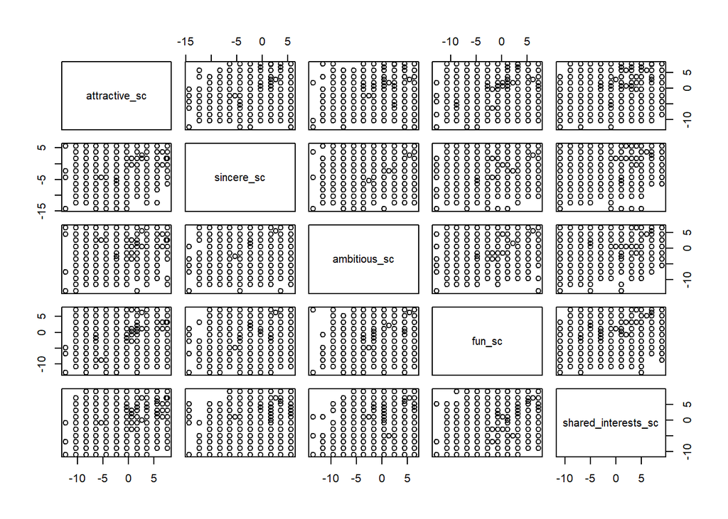

```r
newvars <- c("attractive_sc", "sincere_sc", "ambitious_sc", "fun_sc", "shared_interests_sc")
short_sd <- speed_dating[newvars]
pairs(short_sd)
```

```r
# тут всё ок
```

Попытаемся зафитить модель

```r
fit1 = glmer(decision ~ sex + samerace + attractive_sc + sincere_sc
                 + intelligent_sc
                 + (1|iid), data=speed_dating, family=binomial)
summary(fit1, correlation=F)
```

```
## Generalized linear mixed model fit by maximum likelihood (Laplace
##   Approximation) [glmerMod]
##  Family: binomial  ( logit )
## Formula:
## decision ~ sex + samerace + attractive_sc + sincere_sc + intelligent_sc +
##     (1 | iid)
##    Data: speed_dating
##
##      AIC      BIC   logLik deviance df.resid
##   6944.5   6992.9  -3465.3   6930.5     7359
##
## Scaled residuals:
##      Min       1Q   Median       3Q      Max
## -11.6136  -0.4836  -0.1212   0.4865  20.9732
##
## Random effects:
##  Groups Name        Variance Std.Dev.
##  iid    (Intercept) 2.708    1.645
## Number of obs: 7366, groups:  iid, 498
##
## Fixed effects:
##                Estimate Std. Error z value Pr(>|z|)
## (Intercept)    -0.74340    0.12128  -6.129 8.82e-10 ***
## sexMale         0.15634    0.16397   0.953     0.34
## sameraceYes     0.31357    0.07481   4.192 2.77e-05 ***
## attractive_sc   0.50166    0.01495  33.559  < 2e-16 ***
## sincere_sc      0.08935    0.01555   5.747 9.07e-09 ***
## intelligent_sc  0.14314    0.01739   8.232  < 2e-16 ***
## ---
## Signif. codes:  0 '***' 0.001 '**' 0.01 '*' 0.05 '.' 0.1 ' ' 1
```

```r
fit2 <- glmer(decision ~ intelligent + (1|wave:iid) + (1|sex),
                 data=speed_dating, family=binomial)
summary(fit2, correlation=F)
```

```
## Generalized linear mixed model fit by maximum likelihood (Laplace
##   Approximation) [glmerMod]
##  Family: binomial  ( logit )
## Formula: decision ~ intelligent + (1 | wave:iid) + (1 | sex)
##    Data: speed_dating
##
##      AIC      BIC   logLik deviance df.resid
##   9123.2   9150.8  -4557.6   9115.2     7423
##
## Scaled residuals:
##     Min      1Q  Median      3Q     Max
## -3.3729 -0.7429 -0.4017  0.8217  3.7397
##
## Random effects:
##  Groups   Name        Variance Std.Dev.
##  wave:iid (Intercept) 0.94186  0.9705
##  sex      (Intercept) 0.05707  0.2389
## Number of obs: 7427, groups:  wave:iid, 499; sex, 2
##
## Fixed effects:
##             Estimate Std. Error z value Pr(>|z|)
## (Intercept) -3.91490    0.25175  -15.55   <2e-16 ***
## intelligent  0.48556    0.02385   20.36   <2e-16 ***
## ---
## Signif. codes:  0 '***' 0.001 '**' 0.01 '*' 0.05 '.' 0.1 ' ' 1
```

```r
fit1 <- glmer(decision ~ sex + fun_sc + attractive_sc + sincere_sc
                 + intelligent_sc
                 + (1|iid), data=speed_dating, family=binomial)
summary(fit1, correlation=F)
```

```
## Generalized linear mixed model fit by maximum likelihood (Laplace
##   Approximation) [glmerMod]
##  Family: binomial  ( logit )
## Formula:
## decision ~ sex + fun_sc + attractive_sc + sincere_sc + intelligent_sc +
##     (1 | iid)
##    Data: speed_dating
##
##      AIC      BIC   logLik deviance df.resid
##   6448.4   6496.6  -3217.2   6434.4     7288
##
## Scaled residuals:
##      Min       1Q   Median       3Q      Max
## -13.7887  -0.4350  -0.0824   0.4292  14.1484
##
## Random effects:
##  Groups Name        Variance Std.Dev.
##  iid    (Intercept) 3.273    1.809
## Number of obs: 7295, groups:  iid, 498
##
## Fixed effects:
##                Estimate Std. Error z value Pr(>|z|)
## (Intercept)    -0.72512    0.12856  -5.640 1.70e-08 ***
## sexMale         0.17234    0.17923   0.962  0.33628
## fun_sc          0.28255    0.01466  19.280  < 2e-16 ***
## attractive_sc   0.44298    0.01580  28.043  < 2e-16 ***
## sincere_sc      0.04495    0.01676   2.682  0.00733 **
## intelligent_sc  0.08084    0.01876   4.309 1.64e-05 ***
## ---
## Signif. codes:  0 '***' 0.001 '**' 0.01 '*' 0.05 '.' 0.1 ' ' 1
```

```r
fit1 <- glmer(decision ~ sex + samerace + fun_sc + ambitious_sc + attractive_sc + sincere_sc
                 + intelligent_sc
                 + (1|iid), data=speed_dating, family=binomial)
fit2 <- glmer(decision ~ sex + samerace + fun_sc + ambitious_sc + attractive_sc + sincere_sc
                 + (1|iid), data=speed_dating, family=binomial)
fit3 <- glmer(decision ~ sex + samerace + fun_sc + ambitious_sc + attractive_sc + (1|iid), data=speed_dating, family=binomial)
fit4 <- glmer(decision ~ sex + samerace + fun_sc + ambitious_sc + (1|iid), data=speed_dating, family=binomial)
fit5 <- glmer(decision ~ sex + samerace + (1|iid), data=speed_dating, family=binomial)
```

```r
#anova(fit4, fit5)
```

Так-так, проблемка

```r
sd <- speed_dating[!is.na(speed_dating$intelligent_sc),]
#summary(sd)

sd <- sd[!is.na(sd$sincere_sc),]
summary(sd)
```

```
##       iid         id_win_wave         sex            idg
##  Min.   :  1.0   Min.   : 1.000   Female:3652   Min.   : 1.00
##  1st Qu.:155.5   1st Qu.: 4.000   Male  :3723   1st Qu.: 8.00
##  Median :279.0   Median : 8.000                 Median :16.00
##  Mean   :284.5   Mean   : 9.068                 Mean   :17.55
##  3rd Qu.:405.0   3rd Qu.:13.000                 3rd Qu.:26.00
##  Max.   :552.0   Max.   :22.000                 Max.   :44.00
##                  NA's   :1
##      condtn          wave       n_met_in_wave      position
##  Min.   :1.00   Min.   : 1.00   Min.   : 5.00   Min.   : 1.00
##  1st Qu.:2.00   1st Qu.: 7.00   1st Qu.:15.00   1st Qu.: 4.00
##  Median :2.00   Median :11.00   Median :18.00   Median : 8.00
##  Mean   :1.84   Mean   :11.38   Mean   :16.98   Mean   : 8.97
##  3rd Qu.:2.00   3rd Qu.:15.00   3rd Qu.:20.00   3rd Qu.:13.00
##  Max.   :2.00   Max.   :21.00   Max.   :22.00   Max.   :22.00
##
##    positin1             order           partner        partner_id
##  Length:7375        Min.   : 1.000   Min.   : 1.00   Min.   :  1.0
##  Class :character   1st Qu.: 4.000   1st Qu.: 4.00   1st Qu.:157.0
##  Mode  :character   Median : 8.000   Median : 8.00   Median :280.0
##                     Mean   : 8.904   Mean   : 9.01   Mean   :284.5
##                     3rd Qu.:13.000   3rd Qu.:13.00   3rd Qu.:407.0
##                     Max.   :22.000   Max.   :22.00   Max.   :552.0
##                                                      NA's   :9
##      match           int_corr       samerace    partner_age
##  Min.   :0.0000   Min.   :-0.8300   No :4448   Min.   :18.00
##  1st Qu.:0.0000   1st Qu.:-0.0100   Yes:2927   1st Qu.:24.00
##  Median :0.0000   Median : 0.2200              Median :26.00
##  Mean   :0.1752   Mean   : 0.2028              Mean   :26.38
##  3rd Qu.:0.0000   3rd Qu.: 0.4300              3rd Qu.:28.00
##  Max.   :1.0000   Max.   : 0.9100              Max.   :55.00
##                   NA's   :125                  NA's   :79
##   partner_race     attractive        sincere        intelligent
##  Min.   :1.000   Min.   : 0.000   Min.   : 0.000   Min.   : 0.000
##  1st Qu.:2.000   1st Qu.: 5.000   1st Qu.: 6.000   1st Qu.: 6.000
##  Median :2.000   Median : 6.000   Median : 7.000   Median : 7.000
##  Mean   :2.761   Mean   : 6.194   Mean   : 7.194   Mean   : 7.368
##  3rd Qu.:4.000   3rd Qu.: 8.000   3rd Qu.: 8.000   3rd Qu.: 8.000
##  Max.   :6.000   Max.   :10.000   Max.   :10.000   Max.   :10.000
##  NA's   :53      NA's   :9
```

[output cut: 9 more lines]

```
##  Min.   :-12.379990   Min.   :-14.35033   Min.   :-14.737194
##  1st Qu.: -2.379990   1st Qu.: -2.35033   1st Qu.: -2.737194
##  Median : -0.379990   Median : -0.35033   Median : -0.737194
##  Mean   :  0.007167   Mean   :  0.03828   Mean   : -0.001736
##  3rd Qu.:  3.620010   3rd Qu.:  1.64967   3rd Qu.:  1.262806
##  Max.   :  7.620010   Max.   :  5.64967   Max.   :  5.262806
##  NA's   :9
##      fun_sc           ambitious_sc      shared_interests_sc
##  Min.   :-12.80120   Min.   :-13.5550   Min.   :-10.9491
##  1st Qu.: -2.80120   1st Qu.: -1.5550   1st Qu.: -2.9491
##  Median :  1.19880   Median :  0.4450   Median :  1.0509
##  Mean   :  0.00521   Mean   : -0.0264   Mean   :  0.0235
##  3rd Qu.:  3.19880   3rd Qu.:  2.4450   3rd Qu.:  3.0509
##  Max.   :  7.19880   Max.   :  6.4450   Max.   :  9.0509
##  NA's   :71          NA's   :368        NA's   :728
```

```r
fit0 <- glmer(decision ~ sex + (1|iid), data=sd, family=binomial)
fit1 <- glmer(decision ~ sex + samerace + (1|iid), data=sd, family=binomial)
fit2 <- glmer(decision ~ sex + samerace + sincere_sc + (1|iid), data=sd, family=binomial)
fit3 <- glmer(decision ~ sex + samerace + sincere_sc + intelligent_sc  + (1|iid), data=sd, family=binomial)
```

```r
anova(fit3, fit2, fit1, fit0)
```

```
## Data: sd
## Models:
## fit0: decision ~ sex + (1 | iid)
## fit1: decision ~ sex + samerace + (1 | iid)
## fit2: decision ~ sex + samerace + sincere_sc + (1 | iid)
## fit3: decision ~ sex + samerace + sincere_sc + intelligent_sc + (1 |
## fit3:     iid)
##      Df    AIC    BIC  logLik deviance   Chisq Chi Df Pr(>Chisq)
## fit0  3 9542.0 9562.7 -4768.0   9536.0
## fit1  4 9519.5 9547.2 -4755.8   9511.5  24.455      1  7.605e-07 ***
## fit2  5 9103.8 9138.3 -4546.9   9093.8 417.766      1  < 2.2e-16 ***
## fit3  6 8919.6 8961.1 -4453.8   8907.6 186.135      1  < 2.2e-16 ***
## ---
## Signif. codes:  0 '***' 0.001 '**' 0.01 '*' 0.05 '.' 0.1 ' ' 1
```

```r
summary(fit3)
```

```
## Generalized linear mixed model fit by maximum likelihood (Laplace
##   Approximation) [glmerMod]
##  Family: binomial  ( logit )
## Formula: decision ~ sex + samerace + sincere_sc + intelligent_sc + (1 |
##     iid)
##    Data: sd
##
##      AIC      BIC   logLik deviance df.resid
##   8919.6   8961.1  -4453.8   8907.6     7369
##
## Scaled residuals:
##     Min      1Q  Median      3Q     Max
## -4.0674 -0.7236 -0.3673  0.7898  4.0037
##
## Random effects:
##  Groups Name        Variance Std.Dev.
##  iid    (Intercept) 1.125    1.061
## Number of obs: 7375, groups:  iid, 498
##
## Fixed effects:
##                Estimate Std. Error z value Pr(>|z|)
## (Intercept)    -0.72699    0.08344  -8.712  < 2e-16 ***
## sexMale         0.47081    0.11121   4.233 2.30e-05 ***
## sameraceYes     0.35164    0.06127   5.740 9.49e-09 ***
## sincere_sc      0.11544    0.01215   9.500  < 2e-16 ***
## intelligent_sc  0.18336    0.01383  13.260  < 2e-16 ***
## ---
## Signif. codes:  0 '***' 0.001 '**' 0.01 '*' 0.05 '.' 0.1 ' ' 1
##
## Correlation of Fixed Effects:
##             (Intr) sexMal smrcYs sncr_s
## sexMale     -0.683
## sameraceYes -0.308  0.014
## sincere_sc  -0.033 -0.023  0.056
## intllgnt_sc -0.087  0.075  0.039 -0.444
```

Поищем случайные эффекты. Вроде есть какой-то эффект у wave случайный

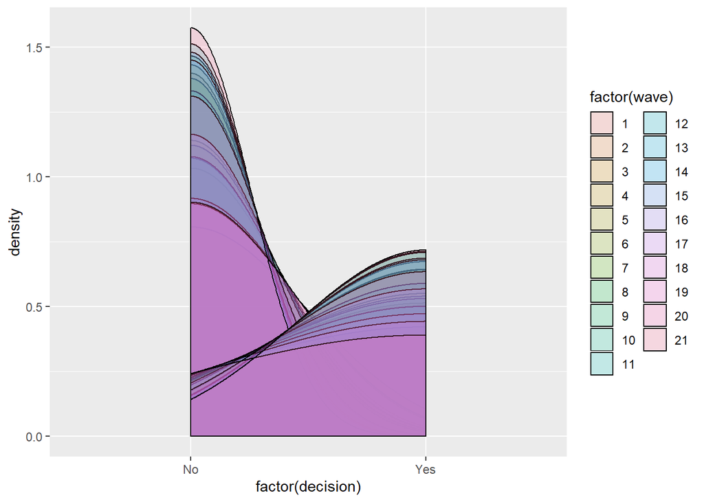

```r
ggplot(speed_dating, aes(x=factor(decision), fill=factor(wave))) +
geom_density(alpha=0.2)
```

```r
fit_r <- glmer(decision ~  sex + samerace + sincere_sc + intelligent_sc + (1|wave:iid),
                 data=sd, family=binomial)
summary(fit_r, correlation=F)
```

```
## Generalized linear mixed model fit by maximum likelihood (Laplace
##   Approximation) [glmerMod]
##  Family: binomial  ( logit )
## Formula: decision ~ sex + samerace + sincere_sc + intelligent_sc + (1 |
##     wave:iid)
##    Data: sd
##
##      AIC      BIC   logLik deviance df.resid
##   8919.6   8961.1  -4453.8   8907.6     7369
##
## Scaled residuals:
##     Min      1Q  Median      3Q     Max
## -4.0674 -0.7236 -0.3673  0.7898  4.0037
##
## Random effects:
##  Groups   Name        Variance Std.Dev.
##  wave:iid (Intercept) 1.125    1.061
## Number of obs: 7375, groups:  wave:iid, 498
##
## Fixed effects:
##                Estimate Std. Error z value Pr(>|z|)
## (Intercept)    -0.72699    0.08344  -8.712  < 2e-16 ***
## sexMale         0.47081    0.11121   4.233 2.30e-05 ***
## sameraceYes     0.35164    0.06127   5.740 9.49e-09 ***
## sincere_sc      0.11544    0.01215   9.500  < 2e-16 ***
## intelligent_sc  0.18336    0.01383  13.260  < 2e-16 ***
## ---
## Signif. codes:  0 '***' 0.001 '**' 0.01 '*' 0.05 '.' 0.1 ' ' 1
```

```r
fit3 <- glmer(decision ~ sex + samerace + sincere_sc + intelligent_sc  + (1|iid), data=sd, family=binomial)
```

```r
anova(fit3, fit_r)
```

```
## Data: sd
## Models:
## fit3: decision ~ sex + samerace + sincere_sc + intelligent_sc + (1 |
## fit3:     iid)
## fit_r: decision ~ sex + samerace + sincere_sc + intelligent_sc + (1 |
## fit_r:     wave:iid)
##       Df    AIC    BIC  logLik deviance Chisq Chi Df Pr(>Chisq)
## fit3   6 8919.6 8961.1 -4453.8   8907.6
## fit_r  6 8919.6 8961.1 -4453.8   8907.6     0      0          1
```

```r
library(stargazer)
stargazer(fit3, type = "text",
          digits = 3,
          star.cutoffs = c(0.05, 0.01, 0.001),
          digit.separator = "")
```

```
##
## =================================================
##                          Dependent variable:
##                     -----------------------------
##                               decision
## -------------------------------------------------
## sexMale                       0.471***
##                                (0.111)
##
## sameraceYes                   0.352***
##                                (0.061)
##
## sincere_sc                    0.115***
##                                (0.012)
##
## intelligent_sc                0.183***
##                                (0.014)
##
## Constant                      -0.727***
##                                (0.083)
##
## -------------------------------------------------
## Observations                    7375
## Log Likelihood                -4453.822
## Akaike Inf. Crit.             8919.644
## Bayesian Inf. Crit.           8961.079
## =================================================
## Note:               *p<0.05; **p<0.01; ***p<0.001
```